# Analysis of longitudinal data

This week we are recreating analysis from Chapter 8 and 9 of the MABS book, but **swapping** the datasets.

## 1. Graphical displays and summary measures on Rats data

### 1-A) Import data

```r
  # load the data
  rats = read_csv('data/rats_long.csv')
  str(rats)
```

```
## spec_tbl_df [176 x 4] (S3: spec_tbl_df/tbl_df/tbl/data.frame)
##  $ ID    : num [1:176] 1 1 1 1 1 1 1 1 1 1 ...
##  $ Group : num [1:176] 1 1 1 1 1 1 1 1 1 1 ...
##  $ Time  : chr [1:176] "WD1" "WD8" "WD15" "WD22" ...
##  $ Weight: num [1:176] 240 250 255 260 262 258 266 266 265 272 ...
##  - attr(*, "spec")=
##   .. cols(
##   ..   ID = col_double(),
##   ..   Group = col_double(),
##   ..   Time = col_character(),
##   ..   Weight = col_double()
##   .. )
```

The rats data contains weekly measurements (over 9 weeks but not always just once a week) of the weight of 16 rats categorized into 3 treatment groups. This leads altogether to 11x16 = 176 observations. I will use the words *treatment*, *group* and *diet* interchangeably.

Let’s create the factor variables again.

```r
rats %<>% mutate(across(c(ID,Group,Time),as_factor))

# Double check that the Time variable is increasing in the levels
rats$Time
```

```
##   [1] WD1  WD8  WD15 WD22 WD29 WD36 WD43 WD44 WD50 WD57 WD64 WD1  WD8  WD15 WD22
##  [16] WD29 WD36 WD43 WD44 WD50 WD57 WD64 WD1  WD8  WD15 WD22 WD29 WD36 WD43 WD44
##  [31] WD50 WD57 WD64 WD1  WD8  WD15 WD22 WD29 WD36 WD43 WD44 WD50 WD57 WD64 WD1
##  [46] WD8  WD15 WD22 WD29 WD36 WD43 WD44 WD50 WD57 WD64 WD1  WD8  WD15 WD22 WD29
##  [61] WD36 WD43 WD44 WD50 WD57 WD64 WD1  WD8  WD15 WD22 WD29 WD36 WD43 WD44 WD50
##  [76] WD57 WD64 WD1  WD8  WD15 WD22 WD29 WD36 WD43 WD44 WD50 WD57 WD64 WD1  WD8
##  [91] WD15 WD22 WD29 WD36 WD43 WD44 WD50 WD57 WD64 WD1  WD8  WD15 WD22 WD29 WD36
## [106] WD43 WD44 WD50 WD57 WD64 WD1  WD8  WD15 WD22 WD29 WD36 WD43 WD44 WD50 WD57
## [121] WD64 WD1  WD8  WD15 WD22 WD29 WD36 WD43 WD44 WD50 WD57 WD64 WD1  WD8  WD15
## [136] WD22 WD29 WD36 WD43 WD44 WD50 WD57 WD64 WD1  WD8  WD15 WD22 WD29 WD36 WD43
## [151] WD44 WD50 WD57 WD64 WD1  WD8  WD15 WD22 WD29 WD36 WD43 WD44 WD50 WD57 WD64
## [166] WD1  WD8  WD15 WD22 WD29 WD36 WD43 WD44 WD50 WD57 WD64
## Levels: WD1 WD8 WD15 WD22 WD29 WD36 WD43 WD44 WD50 WD57 WD64
```

### 1-B) Visual displays

**RAW DATA**

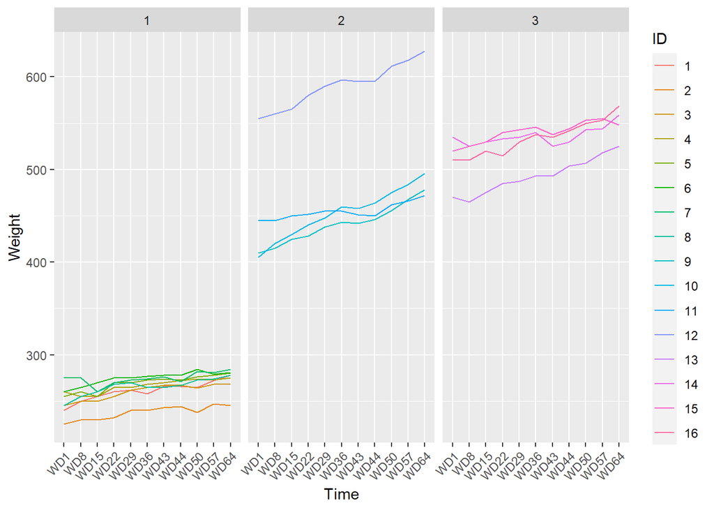

```r
rats %>% ggplot() +
  aes(x = Time, y = Weight, color = ID, group = ID) + geom_line() +
  facet_wrap(~Group) +
  theme(axis.text.x = element_text(angle = 45, hjust = 1, vjust = 1))
```

The facets represent treatments. One can observe that especially in treatment group 2 and 3 the weights of the rats is greatly increasing. Even in treatment 1 (which is likely the control group) one can observe a small increase over time, but note also that these were starting from much lower levels suggesting that those rats were younger (lighter) at the start of the experiment, and this slight increase may be just the general weight-gain during development of adulthood.

**STANDARDIZATION**

It is clearly visible in this plot that individual variation makes it harder to compare the differences between individuals so some sort of standardization is needed. I note here that I think that the used standardization in the MABS book is not the best way to standardize. It is clear for instance that group 2 and 3 rats have started from a much higher weight so of course those treatments (which are diets by the way) would be different from diet 1. If these rats were grown on similar diets *before* the start of the experiment then I think we should normalize each subject to its individual Day 1 weight. I’ll follow this approach, as even though there is no Day 0 observation it is highly unlikely thatthe Day 1 differences are caused by only 1 day of living on the given diet.

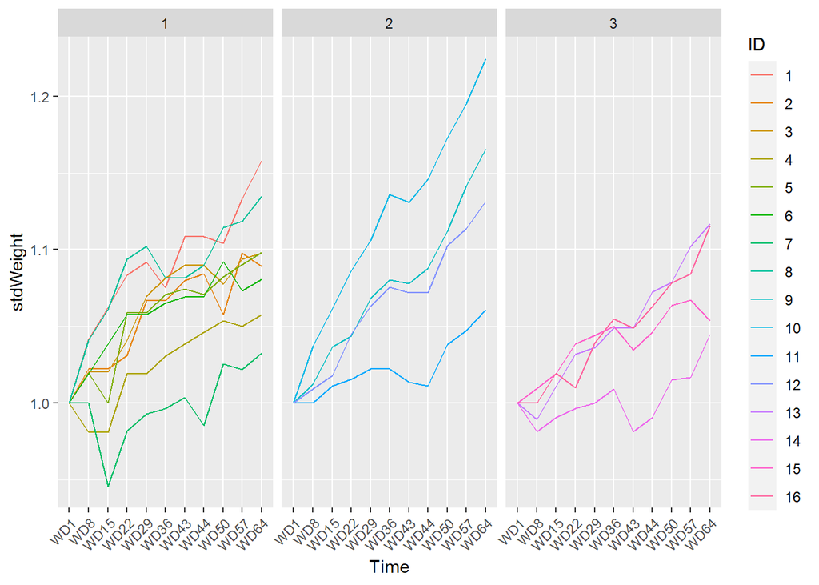

```r
rats %<>% group_by(ID) %>%
  mutate(weightRef = Weight[1], stdWeight = Weight/weightRef) %>%
  dplyr::select(-weightRef)

rats %>% ggplot() +
  aes(x = Time, y = stdWeight, color = ID, group = ID) + geom_line() +
  facet_wrap(~Group) +
  theme(axis.text.x = element_text(angle = 45, hjust = 1, vjust = 1))
```

In this standardized plot everyone is starting from it’s own reference and we see the body weight increase and decrease proportionally to that. The subject experiencing the biggest increase in treatment 2 have gained 20% extra weight during the study. Again, I think this is a fairer comparison that dividing by the observations day’s mean if we are interested in the individual effect of diets.

Let’s visualize this standardized weight on a box-plot stratified by treatment group.

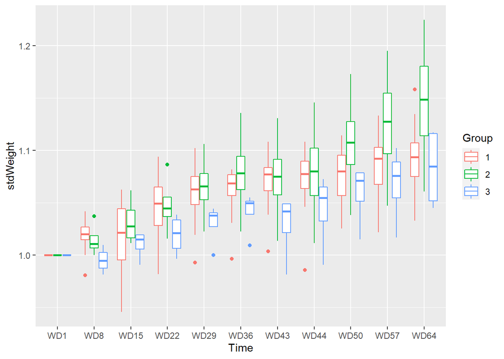

```r
  rats %>% ggplot() +
    aes(x = Time, y = stdWeight, color = Group) + geom_boxplot()
```

This plot reveals that the relative weight-gain of group 3 is always under the other groups. I tend to think that with the original standardization this would not be the case (as the absolute weight of group 3 is relatively high), and indeed that MABS book analysis of this data stated that Group 3 is growing more than group 2 (which is not true in my interpretation). It is interesting to see how Group 1 and 2 start to grow similarly but then around Day 50 the growth of group 2 is taking clearly over.

**SUMMARY MEASURES**

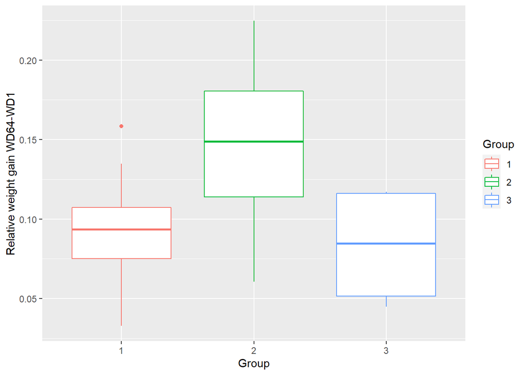

```r
  rats_summ = rats %>% mutate(diffWeight = stdWeight[Time == "WD64"] - stdWeight[Time == "WD1"]) %>%
  summarize(Group = unique(Group), diffWeight = mean(diffWeight))
  rats_summ %>% ggplot() + aes(x = Group, color = Group, y = diffWeight) + geom_boxplot() +
  ylab("Relative weight gain WD64-WD1")
```

**OUTLIER REMOVAL**

I am not a big fan of outlier removal (it sounds like fishing in the data for our desired effects), so I will not perform it here. The boxplots above are anyways not indicative of huge outlier effects, the only outlier point is in group 1 namely

```r
rats_summ %>% filter(Group == 1, diffWeight>0.15)
```

```
## # A tibble: 1 x 3
##   ID    Group diffWeight
##   <fct> <fct>      <dbl>
## 1 1     1          0.158
```

rat no. 1. One could remove it, but I don’t think it’ll ruin the downstream analysis.

**T-TEST**

Let’s perform pairwise t-tests on the groups.

```r
library(rstatix)
rats_summ %>% pairwise_t_test(
    diffWeight ~ Group, paired = FALSE,
    p.adjust.method = "fdr"
  )
```

```
## # A tibble: 3 x 9
##   .y.        group1 group2    n1    n2      p p.signif p.adj p.adj.signif
## * <chr>      <chr>  <chr>  <int> <int>  <dbl> <chr>    <dbl> <chr>
## 1 diffWeight 1      2          8     4 0.0988 ns       0.148 ns
## 2 diffWeight 1      3          8     4 0.718  ns       0.718 ns
## 3 diffWeight 2      3          4     4 0.0858 ns       0.148 ns
```

Despite our observations the differences are non-significant for any pairs. One could increase the sample numbers, or pick a better summary statistic. As expected the smallest p-value is between group 2 and 3 that we identified as over-fed or under-fed groups. Let’s do a final try with the linear model fitting:

```r
fit = rats %>% summarize(Group = unique(Group), baseline = stdWeight[1], weightGain = stdWeight[Time == "WD64"]) %>%
  {lm(weightGain ~ baseline + Group, data = .)}

anova(fit)
```

```
## Analysis of Variance Table
##
## Response: weightGain
##           Df    Sum Sq   Mean Sq F value Pr(>F)
## Group      2 0.0095991 0.0047996  2.1004  0.162
## Residuals 13 0.0297058 0.0022851
```

This is still not significant (but I was not expecting it, as the techniques are very similar in these two cases, and I have taken the baseline already into account during normalization).

## 2. Linear Mixed Effects models

### 2-A) Import data

In this exercise part we’ll deal with the the BPRS (brief psychological response scale) measurements.

```r
bprs = read_csv('data/bprs_long.csv')
str(bprs)
```

```
## spec_tbl_df [360 x 4] (S3: spec_tbl_df/tbl_df/tbl/data.frame)
##  $ treatment: num [1:360] 1 1 1 1 1 1 1 1 1 1 ...
##  $ subject  : num [1:360] 1 1 1 1 1 1 1 1 1 2 ...
##  $ Week     : chr [1:360] "week0" "week1" "week2" "week3" ...
##  $ BPRS     : num [1:360] 42 36 36 43 41 40 38 47 51 58 ...
##  - attr(*, "spec")=
##   .. cols(
##   ..   treatment = col_double(),
##   ..   subject = col_double(),
##   ..   Week = col_character(),
##   ..   BPRS = col_double()
##   .. )
```

The bprs data contains weekly measurements (over 9 weeks including the start of the experiment) of the BPRS of 40 individuals categorized into 2 treatment groups. This leads altogether to 40x9 = 360 observations. I will use the words *treatment* and *group* interchangeably.

Let’s create the factor variables again.

```r
bprs %<>% mutate(across(c(subject,treatment,Week),as_factor))

# Double check that the Week variable is increasing in the levels
levels(bprs$Week)
```

```
## [1] "week0" "week1" "week2" "week3" "week4" "week5" "week6" "week7" "week8"
```

### 2-B) Glimpse on the data

Let’s visualize the data on graphs

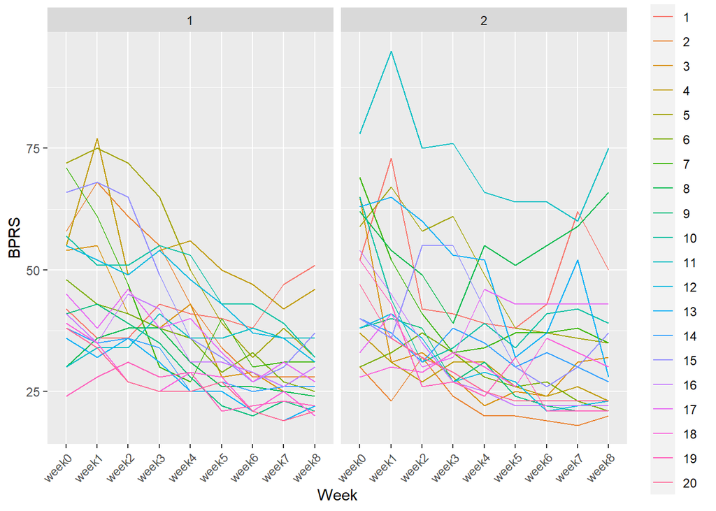

```r
  bprs %>% ggplot() +
    aes(x = Week, y = BPRS, color = subject, group = subject) +
    geom_line() +
    facet_wrap(~treatment) +
    theme(axis.text.x = element_text(angle = 45, hjust = 1, vjust = 1))
```

### 2-C) Linear models

As described in the book, the BPRS measurements are constantly decreasing over time. Let’s do a regression model out of the box (without normalization). The intercept terms should take care of individual differences.

**BASIC LINEAR MODEL**

```r
  bprs_reg = lm(BPRS ~ Week + treatment, data = bprs)
  summary(bprs_reg)
```

```
##
## Call:
## lm(formula = BPRS ~ Week + treatment, data = bprs)
##
## Residuals:
##     Min      1Q  Median      3Q     Max
## -23.714  -9.226  -2.989   6.786  48.389
##
## Coefficients:
##             Estimate Std. Error t value Pr(>|t|)
## (Intercept)  47.7139     2.0590  23.173  < 2e-16 ***
## Weekweek1    -1.6750     2.7624  -0.606  0.54467
## Weekweek2    -6.3000     2.7624  -2.281  0.02317 *
## Weekweek3    -8.8500     2.7624  -3.204  0.00148 **
## Weekweek4   -11.6500     2.7624  -4.217 3.15e-05 ***
## Weekweek5   -15.4500     2.7624  -5.593 4.51e-08 ***
## Weekweek6   -16.7750     2.7624  -6.073 3.28e-09 ***
## Weekweek7   -15.8000     2.7624  -5.720 2.29e-08 ***
## Weekweek8   -16.5750     2.7624  -6.000 4.92e-09 ***
## treatment2    0.5722     1.3022   0.439  0.66063
## ---
## Signif. codes:  0 '***' 0.001 '**' 0.01 '*' 0.05 '.' 0.1 ' ' 1
##
## Residual standard error: 12.35 on 350 degrees of freedom
## Multiple R-squared:  0.2026, Adjusted R-squared:  0.182
## F-statistic: 9.878 on 9 and 350 DF,  p-value: 1.62e-13
```

The summary indicates that the treatment variable do not have a significant effect on the outcome. However the passing of time makes a significant difference as shown by the Week values. This model has assumed independence which is probably not true in this case (the subjects are the same over time so likely they are not independent).

**RANDOM INTERCEPT MODEL**

```r
  library(lme4)
  bprs_ref <- lmer(BPRS ~ Week + treatment + (1 | subject), data = bprs, REML = FALSE)
  summary(bprs_ref)
```

```
## Linear mixed model fit by maximum likelihood  ['lmerMod']
## Formula: BPRS ~ Week + treatment + (1 | subject)
##    Data: bprs
##
##      AIC      BIC   logLik deviance df.resid
##   2751.3   2798.0  -1363.7   2727.3      348
##
## Scaled residuals:
##     Min      1Q  Median      3Q     Max
## -3.2309 -0.6213 -0.1018  0.4877  3.3537
##
## Random effects:
##  Groups   Name        Variance Std.Dev.
##  subject  (Intercept)  47.6     6.899
##  Residual             100.8    10.039
## Number of obs: 360, groups:  subject, 20
##
## Fixed effects:
##             Estimate Std. Error t value
## (Intercept)  47.7139     2.2758  20.965
## Weekweek1    -1.6750     2.2448  -0.746
## Weekweek2    -6.3000     2.2448  -2.807
## Weekweek3    -8.8500     2.2448  -3.942
## Weekweek4   -11.6500     2.2448  -5.190
## Weekweek5   -15.4500     2.2448  -6.883
## Weekweek6   -16.7750     2.2448  -7.473
## Weekweek7   -15.8000     2.2448  -7.039
## Weekweek8   -16.5750     2.2448  -7.384
## treatment2    0.5722     1.0582   0.541
##
## Correlation of Fixed Effects:
##            (Intr) Wekwk1 Wekwk2 Wekwk3 Wekwk4 Wekwk5 Wekwk6 Wekwk7 Wekwk8
## Weekweek1  -0.493
## Weekweek2  -0.493  0.500
## Weekweek3  -0.493  0.500  0.500
## Weekweek4  -0.493  0.500  0.500  0.500
## Weekweek5  -0.493  0.500  0.500  0.500  0.500
## Weekweek6  -0.493  0.500  0.500  0.500  0.500  0.500
## Weekweek7  -0.493  0.500  0.500  0.500  0.500  0.500  0.500
## Weekweek8  -0.493  0.500  0.500  0.500  0.500  0.500  0.500  0.500
## treatment2 -0.232  0.000  0.000  0.000  0.000  0.000  0.000  0.000  0.000
```

This indicates also no significant effect of the treatment on the BPRS outputs.

**RANDOM SLOPE MODEL**

```r
  bprs_refslope <- lmer(BPRS ~ Week + treatment + (Week | subject), data = bprs, REML = FALSE)
```

```
## boundary (singular) fit: see help('isSingular')
```

```r
  summary(bprs_refslope)
```

```
## Linear mixed model fit by maximum likelihood  ['lmerMod']
## Formula: BPRS ~ Week + treatment + (Week | subject)
##    Data: bprs
##
##      AIC      BIC   logLik deviance df.resid
##   2825.5   3043.1  -1356.7   2713.5      304
##
## Scaled residuals:
##     Min      1Q  Median      3Q     Max
## -3.0214 -0.5624 -0.0749  0.5371  3.3227
##
## Random effects:
##  Groups   Name        Variance Std.Dev. Corr
##  subject  (Intercept) 52.035   7.214
##           Weekweek1   11.038   3.322     0.33
##           Weekweek2    8.858   2.976     0.09  0.68
##           Weekweek3   15.579   3.947     0.00  0.92  0.83
##           Weekweek4   24.598   4.960    -0.45  0.66  0.37  0.78
##           Weekweek5   30.384   5.512    -0.58  0.47  0.12  0.58  0.96
##           Weekweek6   43.630   6.605    -0.53  0.49  0.08  0.58  0.96  1.00
##           Weekweek7   50.055   7.075    -0.41  0.57  0.09  0.61  0.95  0.98
##           Weekweek8   52.016   7.212    -0.33  0.64  0.15  0.66  0.96  0.96
##  Residual             90.726   9.525
##
##
##
##
##
##
##
##
##   0.99
##   0.98  1.00
##
## Number of obs: 360, groups:  subject, 20
##
## Fixed effects:
##             Estimate Std. Error t value
## (Intercept)  47.7139     2.2632  21.083
## Weekweek1    -1.6750     2.2557  -0.743
## Weekweek2    -6.3000     2.2314  -2.823
## Weekweek3    -8.8500     2.3055  -3.839
## Weekweek4   -11.6500     2.4013  -4.852
## Weekweek5   -15.4500     2.4608  -6.278
## Weekweek6   -16.7750     2.5919  -6.472
## Weekweek7   -15.8000     2.6531  -5.955
## Weekweek8   -16.5750     2.6715  -6.204
## treatment2    0.5722     1.0040   0.570
##
## Correlation of Fixed Effects:
##            (Intr) Wekwk1 Wekwk2 Wekwk3 Wekwk4 Wekwk5 Wekwk6 Wekwk7 Wekwk8
## Weekweek1  -0.367
## Weekweek2  -0.430  0.517
## Weekweek3  -0.434  0.552  0.535
## Weekweek4  -0.566  0.519  0.474  0.548
## Weekweek5  -0.614  0.486  0.431  0.512  0.606
## Weekweek6  -0.601  0.479  0.406  0.505  0.616  0.640
## Weekweek7  -0.552  0.491  0.400  0.510  0.618  0.640  0.667
## Weekweek8  -0.519  0.504  0.407  0.522  0.620  0.636  0.663  0.678
## treatment2 -0.222  0.000  0.000  0.000  0.000  0.000  0.000  0.000  0.000
## optimizer (nloptwrap) convergence code: 0 (OK)
## boundary (singular) fit: see help('isSingular')
```

```r
  anova(bprs_ref,bprs_refslope)
```

```
## Data: bprs
## Models:
## bprs_ref: BPRS ~ Week + treatment + (1 | subject)
## bprs_refslope: BPRS ~ Week + treatment + (Week | subject)
##               npar    AIC    BIC  logLik deviance  Chisq Df Pr(>Chisq)
## bprs_ref        12 2751.3 2798.0 -1363.7   2727.3
## bprs_refslope   56 2825.5 3043.1 -1356.7   2713.5 13.837 44          1
```

Even the addition of the time variable to the random effects cannot make a difference between the groups.

**RANDOM INTERCEPT AND SLOPE WITH INTERACTION MODEL**

```r
  bprs_refslopeinteract <- lmer(BPRS ~ Week * treatment + (Week | subject), data = bprs, REML = FALSE)
```

```
## boundary (singular) fit: see help('isSingular')
```

```r
  summary(bprs_refslopeinteract)
```

```
## Linear mixed model fit by maximum likelihood  ['lmerMod']
## Formula: BPRS ~ Week * treatment + (Week | subject)
##    Data: bprs
##
##      AIC      BIC   logLik deviance df.resid
##   2832.7   3081.4  -1352.3   2704.7      296
##
## Scaled residuals:
##     Min      1Q  Median      3Q     Max
## -3.1490 -0.5778 -0.0824  0.5461  3.4514
##
## Random effects:
##  Groups   Name        Variance Std.Dev. Corr
##  subject  (Intercept) 53.24    7.296
##           Weekweek1   11.78    3.432     0.28
##           Weekweek2   10.49    3.239     0.03  0.70
##           Weekweek3   17.74    4.212    -0.05  0.92  0.85
##           Weekweek4   26.40    5.138    -0.47  0.68  0.42  0.79
##           Weekweek5   31.65    5.626    -0.59  0.49  0.16  0.60  0.96
##           Weekweek6   45.18    6.722    -0.54  0.50  0.12  0.58  0.95  1.00
##           Weekweek7   51.65    7.187    -0.42  0.58  0.13  0.61  0.95  0.98
##           Weekweek8   53.79    7.334    -0.35  0.65  0.18  0.66  0.95  0.96
##  Residual             88.10    9.386
##
##
##
##
##
##
##
##
##   0.99
##   0.98  1.00
##
## Number of obs: 360, groups:  subject, 20
##
## Fixed effects:
##                      Estimate Std. Error t value
## (Intercept)            47.000      2.658  17.680
## Weekweek1              -0.200      3.066  -0.065
## Weekweek2              -3.450      3.055  -1.129
## Weekweek3              -6.100      3.114  -1.959
## Weekweek4             -10.400      3.183  -3.268
## Weekweek5             -14.300      3.224  -4.436
## Weekweek6             -17.300      3.327  -5.200
## Weekweek7             -17.200      3.375  -5.096
## Weekweek8             -17.700      3.391  -5.220
## treatment2              2.000      2.968   0.674
## Weekweek1:treatment2   -2.950      4.197  -0.703
## Weekweek2:treatment2   -5.700      4.197  -1.358
## Weekweek3:treatment2   -5.500      4.197  -1.310
## Weekweek4:treatment2   -2.500      4.197  -0.596
## Weekweek5:treatment2   -2.300      4.197  -0.548
## Weekweek6:treatment2    1.050      4.197   0.250
## Weekweek7:treatment2    2.800      4.197   0.667
## Weekweek8:treatment2    2.250      4.197   0.536
```

```
##
## Correlation matrix not shown by default, as p = 18 > 12.
## Use print(x, correlation=TRUE)  or
##     vcov(x)        if you need it
```

```
## optimizer (nloptwrap) convergence code: 0 (OK)
## boundary (singular) fit: see help('isSingular')
```

```r
  anova(bprs_refslope,bprs_refslopeinteract)
```

```
## Data: bprs
## Models:
## bprs_refslope: BPRS ~ Week + treatment + (Week | subject)
## bprs_refslopeinteract: BPRS ~ Week * treatment + (Week | subject)
##                       npar    AIC    BIC  logLik deviance  Chisq Df Pr(>Chisq)
## bprs_refslope           56 2825.5 3043.1 -1356.7   2713.5
## bprs_refslopeinteract   64 2832.7 3081.4 -1352.3   2704.7 8.7954  8     0.3599
```